# Chapter 5: The Rcpp Package

2016-10-05

## 5.1 Introduction

## 5.1 Introduction

- Sometimes R is just slow.
- You've tried every trick you know, and your code is still crawling along
- Rewrite code in C/C++
  - Using `.Call` is very painful

## Rcpp

- There's a better way! Rcpp!
  - In this chapter, C and C++ code are largely [interchangeable](http://programmers.stackexchange.com/q/16390/14846)
- Goal: provide a flavour of what's possible.
  - No previous C++ experience

## Exercise: Are you ready?

```r
install.packages("Rcpp")
```

```r
nclRbig::test_rcpp()
```

```
## Everything seems fine
```

See Pre-requisites in the notes if you have problems

## 5.2 A simple C++ function

## 5.2 A simple C++ function

```r
## R version
add_r = function(x, y) {
  return(x + y)
}
```

```cpp
/* Return type double
 * Two arguments, also doubles
 */
double add_c(double x, double y) {
    double value = x + y;
    return value;
}
```

> Exercise: What differences do you see?

## The `main` function

- Typically we need a function `main`; not here.
- Rcpp makes it easy to call C++ functions from R
- Users doen't have to worry about
  - platform;
  - compilers;
  - R/C interface.

## The `cppFunction` command

```r
library("Rcpp")
cppFunction('
  double add_c(double x, double y){
    double value = x + y;
    return value;
  }
')
```

Rcpp then performs magic!

## The magic

```r
add_c
```

```
## function (x, y)
## .Primitive(".Call")(<pointer: 0x7fe7d74bdf80>, x, y)
```

We can call the `add_c`} function in the usual way

```r
add_c(1, 2)
```

```
## [1] 3
```

## Chapter 3: Exercise 1

## Chapter 3: Exercise 1

```r
vignette("Rcpp", package="nclRbig")
```

## 5.2.2 C/C++ data types

## 5.2.2 C/C++ data types

| Type | Description |
| --- | --- |
| `char` | A single character. |
| `int` | An integer. |
| `float` | A single precision floating point number. |
| `double` | A double-precision floating point number. |
| `void` | A valueless quantity. |

There are also `pointer`'s

## 5.3 The sourceCpp function

## 5.3 The sourceCpp function

- The `cppFunction` is great for small examples
- But you should put C++ code in a separate file (`.cpp`)
  - `sourceCpp("path/to/file.cpp")`
- The `.cpp` needs a few headers

## `.Cpp` components

Access Rcpp functions (similar to a `library` call)

```cpp
#include <Rcpp.h>
```

## Namespace

- To access the Rcpp functions we would have to type `Rcpp::function_1`
- To avoid typing `Rcpp::`

  ```cpp
  using namespace Rcpp;
  ```

- Above each function we want to export/use in R

  ```cpp
  // [[Rcpp::export]]
  ```

## Complete file

```cpp
# include <Rcpp.h>
using namespace Rcpp;

// [[Rcpp::export]]
double add_c(double x, double y) {
  double value = x + y;
  return value;
}
```

## Benefits of a file

1. Syntax highlighting
2. It's easy to make errors switching between R and C++ in the same file

To save space, we we'll omit the headers for the remainder of the chapter.

## Exercise 2

## Exercise 2

```r
vignette("Rcpp", package="nclRbig")
```

## 5.4 Vectors and loops

## `mean_r`

```r
mean_r = function(x) {
  n = length(x)
  m = 0
  for(i in seq_along(x))
    m = m + x[i]/n
  m
}
```

## `mean_c`

```cpp
double mean_c(NumericVector x){
  int i;
  int n = x.size();
  double mean = 0;

  for(i=0; i<n; i++) {
    mean = mean + x[i]/n;
  }
  return mean;
}
sourceCpp("../src/mean_c.cpp")
```

## Speed comparison

```r
library("microbenchmark")
```

We generate some normal random numbers for the comparison

```r
x = rnorm(1e4)
```

Then call the `microbenchmark` function.

```r
z = microbenchmark(
  mean(x),
  mean_r(x),
  mean_c(x)
)
```

## Results

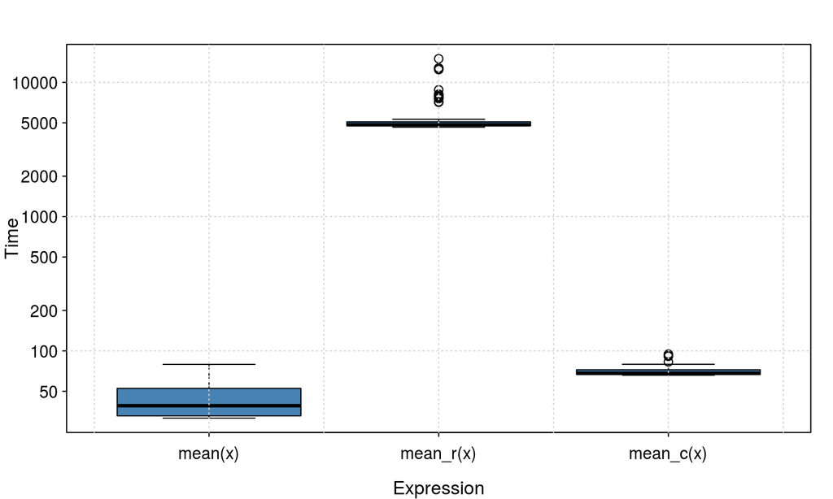

## Exercise 3

## Exercise 3

```r
vignette("Rcpp", package="nclRbig")
```

## 5.5 C++ with sugar on top

## 5.5 The sugared version

- Rcpp sugar brings a higher-level of abstraction to C++ code written using the Rcpp API.

```cpp
NumericVector res_c(NumericVector x, NumericVector y) {
  int i;
  int n = x.size();
  NumericVector residuals(n);
  for(i=0; i<n; i++) {
    residuals[i] = pow(x[i] - y[i], 2);
  }
  return residuals;
}
```

## With Sugar

```cpp
NumericVector res_sugar(NumericVector x, NumericVector y) {
  return pow(x - y, 2);
}
```

- The sugar versions aren't usually faster than the C++ version,
  - but there's usually very little difference between the two.
- However with the sugared variety, the code is shorter and is constantly being improved.